# Python as a Calulator

```python
# This is a comment.
3 + 5 - 4
4/5 * 3
2**10
from math import *
factorial(52)
```

```
80658175170943878571660636856403766975289505440883277824000000000000
```

# Symbolic Math with Python

```python
from sympy import *
a, x = symbols('a, x')
factor(x**2 + 2*x*a +a**2)
```

$\displaystyle \left(a + x\right)^{2}$

```python
diff(x**2 + 2*x*a +a**2, x)
```

$\displaystyle 2 a + 2 x$

```python
integrate(2*a + 2*x, (x, -1, 1))
```

$\displaystyle 4 a$

# Plotting Symbolic equation

```python
from sympy.plotting import plot
from sympy import Symbol
# SSSSSSymbol = work with one variable
x = Symbol('x')
plot(x**2)
```

```
    100 |\                                                     /
        | .                                                   .
        |  .                                                 .
        |   \                                               /
        |    .                                             .
        |     .                                           .
        |      \                                         /
        |       \                                       /
     50 |--------\-------------------------------------/--------
        |         \                                   /
        |          \                                 /
        |           \                               /
        |            \                             /
        |             ..                         ..
        |               \                       /
        |                ..                   ..
        |                  ..               ..
        |                    ...         ...
      0 |_______________________________________________________
         -10                        0                          10
```

```
<sympy.plotting.plot.Plot at 0x18a86d6ffd0>
```

# Numerical Math Using Python

```python
import numpy as np
a = list(range(4))
a[0], a[1], a[2], a[3]
A = np.array([[1, 2], [3, 4]])
A
```

```
array([[1, 2],
       [3, 4]])
```

# Simple Numerical Plots

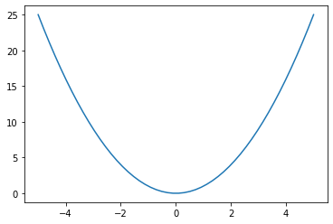

```python
import numpy as np
import matplotlib.pyplot as plt
x = np.linspace(-5, 5, 50)
y = x**2
plt.plot(x,y)
```

# Exercise 1: Pythagoras' theorem

```python
from math import *
asin(pi/4)
```

```
0.9033391107665127
```

Show how to use Python to compute Angle C

```python
AB = 4
AC = 3
BC = 5
degrees(asin(AB/BC))
```

```
53.13010235415599
```

Show how to use Python to compute length of AD.

```python
AB = 2
BD = 1
CD = 1
b = radians(60)
AD = AB * sin(b)
AD
```

```
1.7320508075688772
```

```python
AD ** 2 # ~3
# since, 1^2 + 3^(2/2) = 2^2
```

```
2.9999999999999996
```

# Solving Equations

```python
from sympy import Symbol, solve
x = Symbol('x')
expr = x - 5 - 7
solve(expr)
```

```
[12]
```

# Solving Quadratic Equations

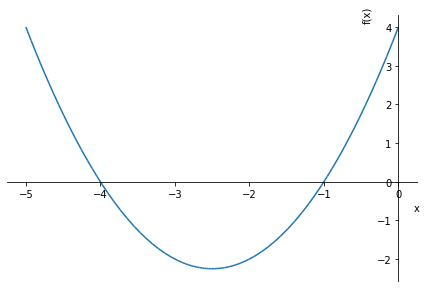

```
<sympy.plotting.plot.Plot at 0x18a9e615670>
```

```python
from sympy import solve
from sympy.plotting import plot
x = Symbol('x')
expr = x**2 + 5*x + 4
solve(expr, dict=True)
# The second argument to the solve() function (dict=True) specifies that we want the result to be returned as a list of Python dictionaries.

plot(expr, (x,-5, 0))   # Noted that you can specify x domain of the plot
```

# Exercise 2: Solving Equation

If you want to calculate the distance traveled by a falling object, you need to write down the equation of motion. If the initial displacement and velocity are both equal to zero, it boils down to:

\begin{align} s=\frac{1}{2}gt^2 \end{align}

s: Distance or Hight of falling object in meter \begin{align} g:=9.8\frac{m}{s^2} \end{align} t: time in second

Find out time for falling object at 120 meters from HIGHTOWER. Show graph of falling equation intersec x-axis.

```
[{t: -4.94871659305393}, {t: 4.94871659305393}]
```

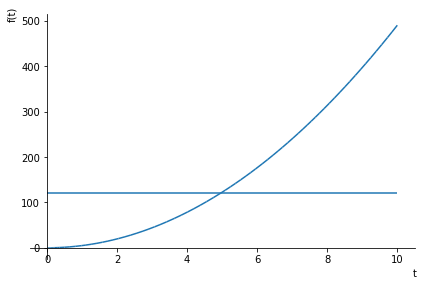

```
<sympy.plotting.plot.Plot at 0x18a9d3444c0>
```

```python
from sympy import solve, Symbol
from sympy.plotting import plot
g = 9.8
t = Symbol("t")
s = 1/2 * g * t**2
sn = 120
print(o := solve((s - sn), dict=True))
plot(s, 120, (t, 0, 10))
```

```python
o[1][t]**2 * g * 1/2 # ~ 120
```

$\displaystyle 120.0$

# Solving a System of Linear Equations

\begin{align} 2x+3y=6 \end{align}\begin{align} 3x+2y=12 \end{align}

```
[{x: 24/5, y: -6/5}]
```

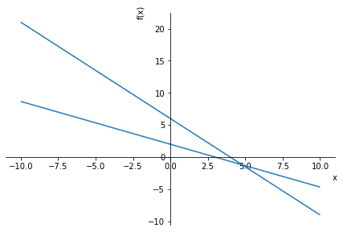

```
<sympy.plotting.plot.Plot at 0x18a9a3220d0>
```

```python
from sympy import *
from sympy.plotting import plot
x, y = symbols('x,y')
expr1 = 2*x + 3*y - 6
expr2 = 3*x + 2*y-12
print(solve((expr1, expr2), dict=True))
pexp1= (-2*x+6)/3
pexp2 = (-3*x +12)/2
plot(pexp1, pexp2)
```

# Exercise 3: Solving Linear Equation

Find the Point of Intersection of Two Lines of equations from following sale man problem. Show grap of Intersection point.

You are running a concession stand at a university soccer game. You are selling hot dogs and sodas. Each hot dog costs 15 baht and each soda costs 32 baht. At the end of the night you made a total of 2,247 baht.

You sold a total of 110 hot dogs and sodas combined. You must report the number of hot dogs sold and the number of sodas sold. How many hot dogs were sold and how many sodas were sold?

```python
h = Symbol("h")
s = Symbol("s")
expr1 = 15 * h + 32 * s - 2247
expr2 = h + s - 110
solve((expr1, expr2), dict=True)
```

```
[{h: 1273/17, s: 597/17}]
```

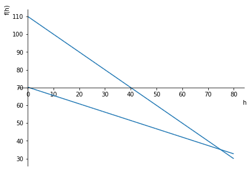

```
<sympy.plotting.plot.Plot at 0x18a9e3b7ee0>
```

```python
p_e1 = -(15 * h -2247) / 32
p_e2 = -(h - 110)
plot(p_e1, p_e2, (h, 0, 80))
```

```python
x = np.array([[15, 32], [1, 1]])
y = np.linalg.inv(x)
z = np.array([2247, 110])
y @ z
```

```
array([74.88235294, 35.11764706])
```